# Extended War Report

2025-08-26

# Overview

This is an extended war report for the war **29763** between **Torn Community Garden** and **Die Blade**. Data is presented from the side of **Torn Community Garden**. Link to the official war report can be found [HERE](https://www.torn.com/war.php?step=rankreport&rankID=29763).

## Rewards

War outcome for your faction: **Victory**  
Total hits done: **1170**  
War hits: **903**  
Non war hits: **267**  
Total respect earned: **6304.26**  
Members contributed: **27/28**

Rewards for your faction:

| Name | Amount | Price |
| --- | --- | --- |
| Medium Arms Cache | 3 | 612.11 M |
| Small Arms Cache | 2 | 241.94 M |
| Armor Cache | 2 | 651.55 M |

Earnings from caches: **1.51 B**  
Total earnings: **1.51 B**<sup>1</sup>

<sup>1</sup>prices are based on market value or approximate trader prices if market value is unavaliable.

## War Preparation

**NOTE**: Faction Xanax might be different from Prep Xanax due to how personal stats are calculated. In this case, Faction Xanax is more accurate.

Members who **did not stack** energy before war:

|  | Name | Prep_Xanax | Faction_Xanax | Total_Hits |
| --- | --- | --- | --- | --- |
| 1 | Darnclip | 1 |  | 5 |
| 2 | Goose_wayne | 3 |  | 14 |
| 3 | Harleequiin | 3 |  | 35 |
| 4 | Jannerboy | 1 | 1 | 20 |
| 5 | JaxieBear | 3 | 2 | 21 |
| 6 | MirandaWarning | 0 |  | 2 |
| 7 | SomeBOT | 1 | 1 | 0 |
| 8 | solty | 0 |  | 31 |

Members who **overdosed** during war preparations (but could still have stacked):

|  | Name | Prep_Xanax | Faction_Xanax | Total_Hits |
| --- | --- | --- | --- | --- |
| 1 | Chapelle | 4 | 5 | 15 |
| 2 | Happymeal | 5 | 1 | 37 |
| 3 | RipleyWolf | 9 | 10 | 78 |
| 4 | ScatterBean | 9 | 9 | 77 |

Members who **most likely stacked** energy before war (or just used lots of xanax):

|  | Name | Prep_Xanax | Faction_Xanax | Total_Hits |
| --- | --- | --- | --- | --- |
| 1 | 25mg-brenadryl | 4 | 4 | 13 |
| 2 | Benedicc | 7 | 7 | 58 |
| 3 | BillTheImpaler | 6 | 4 | 13 |
| 4 | Blazinowl | 7 | 3 | 42 |
| 5 | EYJL | 4 | 4 | 77 |
| 6 | FogBorne | 4 | 4 | 50 |
| 7 | Merle-DicksIn | 10 | 4 | 83 |
| 8 | MrLuther | 8 | 2 | 42 |
| 9 | Mystic_Music | 4 | 4 | 54 |
| 10 | NatsuSensei | 6 | 4 | 22 |

[output cut: 6 more lines]

## Fighting summary

### Top 5

Top 5 by overall contribution %

| Name | Contribution |
| --- | --- |
| Supreme_ | 9.91 |
| ThePickles | 7.78 |
| Merle-DicksIn | 7.09 |
| Soultea | 6.67 |
| RipleyWolf | 6.67 |

Top 5 by War hits

| Name | War_Hits |
| --- | --- |
| Merle-DicksIn | 82 |
| EYJL | 76 |
| ThePickles | 72 |
| RipleyWolf | 57 |
| Benedicc | 54 |

Top 5 by Non War hits

| Name | Non_War_Hits |
| --- | --- |
| Supreme_ | 80 |
| Soultea | 51 |
| ScatterBean | 23 |
| RipleyWolf | 21 |
| ThePickles | 19 |

Top 5 by Total hits

| Name | Total_Hits |
| --- | --- |
| Supreme_ | 116 |
| ThePickles | 91 |
| Merle-DicksIn | 83 |
| Soultea | 78 |
| RipleyWolf | 78 |

Top 5 by Assists

| Name | Assists |
| --- | --- |
| SixtenBlixt | 4 |
| Harleequiin | 4 |
| BillTheImpaler | 4 |
| RipleyWolf | 4 |
| solty | 3 |

Chain savers - List of people who saved the chain with less than 60 seconds remaining.

```
## [1] "Friendly chain savers:"
```

| Saver | Chain | Time remaining |
| --- | --- | --- |
| ScatterBean | 351 | 24 |
| ScatterBean | 295 | 57 |
| RipleyWolf | 258 | 27 |
| ThePickles | 256 | 51 |
| SixtenBlixt | 145 | 22 |
| EYJL | 143 | 5 |
| EYJL | 142 | 28 |
| ThePickles | 137 | 59 |
| solty | 85 | 56 |

```
## [1] "Enemy chain savers:"
```

| Saver | Chain | Time remaining |
| --- | --- | --- |
| Snappymoses | 258 | 18 |
| Sanctum | 251 | 40 |
| RrrrrRrrrrrruff | 230 | 4 |
| RrrrrRrrrrrruff | 205 | 23 |
| RrrrrRrrrrrruff | 203 | 36 |
| Sanctum | 203 | 41 |
| Jherek | 202 | 10 |
| RrrrrRrrrrrruff | 187 | 46 |
|  | 180 | 50 |
|  | 179 | 38 |
| Sanctum | 177 | 60 |
| Jherek | 163 | 10 |
| Sanctum | 159 | 32 |
| Sanctum | 153 | 19 |
|  | 148 | 55 |
| Sanctum | 142 | 31 |
| Sanctum | 141 | 38 |
| Sanctum | 130 | 52 |
|  | 122 | 20 |
| Sanctum | 116 | 44 |
| Sanctum | 65 | 25 |

### Visual summary

Only including members with non-zero contribution

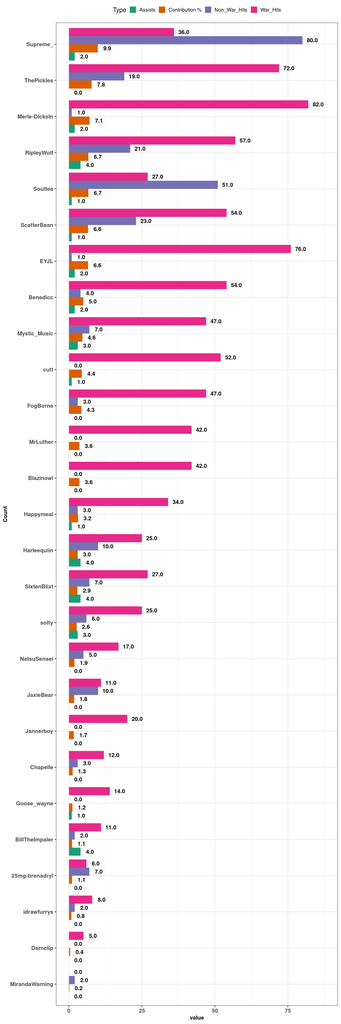

### Respect

Respect earned by each member.<sup>1</sup>  
Total respect earned: **6304.26**  
Total respect lost: **804.98**  
Net respect change: **5499.28**<sup>2</sup>  
Average respect earned per attack: **4.8**

<sup>1</sup>Chain bonuses are ignored in per-member contributions.  
<sup>2</sup>Respect lost will be 0 if using non-faction API key.

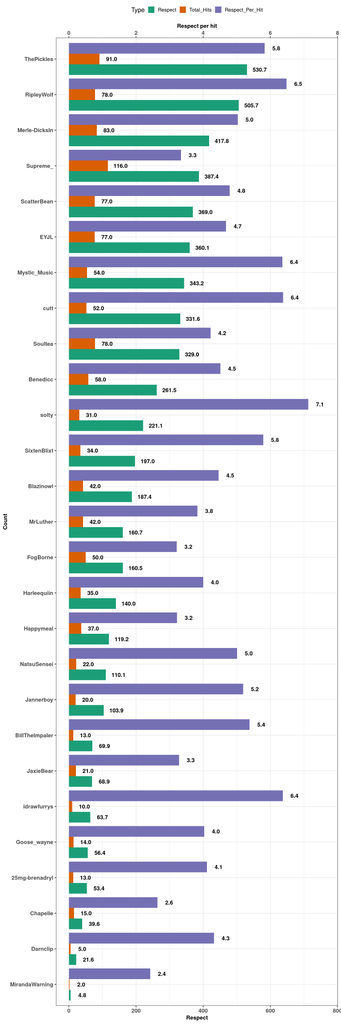

### War Score

Looking at war score gained and lost by each member.  
**The calculations IGNORE chain bonuses in order to better reflect actual contribution rather than landing a lucky hit**  
Total score earned: **4909.17**  
Total score lost: **2279.56**<sup>1</sup>  
Median net score per member: **99.68**<sup>2</sup>

<sup>1</sup>Score lost will be 0 if using non-faction API key.  
<sup>2</sup>Using median instead of mean to avoid extreme values skewing the metric.

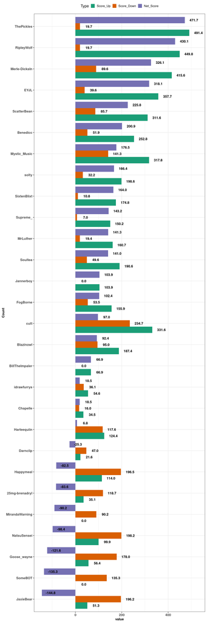

### Slackers

Members who did not meet 1% contribution cutoff

| Name | Contribution |
| --- | --- |
| idrawfurrys | 0.85 |
| Darnclip | 0.43 |
| MirandaWarning | 0.17 |
| SomeBOT | 0.00 |

### Energy

Summary of who wasted the most energy and who cost the enemy the most energy.  
Calculated by adding up Losses (and Stalemates, Defends, Escapes, Interrupts) and Defends, the multiplying the number by 25.  
E_Wasted means the member spent X energy on attacks that failed.  
E_Stolen means X energy was wasted by the enemy on attacking the member unsuccessfully.  
You might want to take a closer look at members with high E_Wasted values and remind them to pick fights they can win!

<sup>1</sup> These numbers will be 0 if you are using an API key WITHOUT faction access.

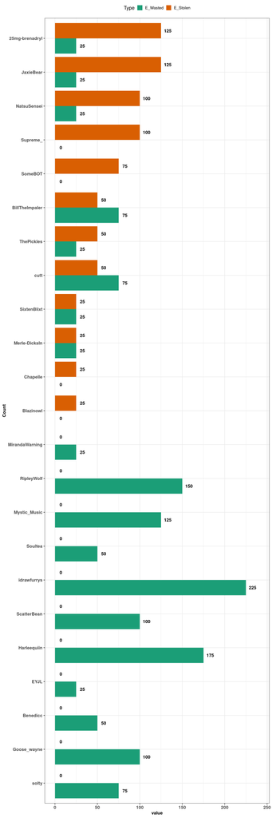

### Full table

Full table with filters and search

|  | Name | Total_Hits | Contribution | War_Hits | Non_War_Hits | Assists | Respect | Respect_Per_Hit | Respect_Lost | Score_Up | Score_Down | Net_Score |
| --- | --- | --- | --- | --- | --- | --- | --- | --- | --- | --- | --- | --- |
| 1 | solty | 31 | 2.65 | 25 | 6 | 3 | 221.13 | 7.13 | 9.459999999999999 | 198.6300000000001 | 32.19 | 166.44 |
| 2 | Blazinowl | 42 | 3.59 | 42 | 0 | 0 | 187.44 | 4.46 | 26.03 | 187.44 | 95.02000000000001 | 92.42 |
| 3 | Happymeal | 37 | 3.16 | 34 | 3 | 1 | 119.23 | 3.22 | 49.75000000000001 | 114 | 196.52 | -82.52 |
| 4 | Goose_wayne | 14 | 1.2 | 14 | 0 | 1 | 56.40000000000001 | 4.03 | 44.55 | 56.40000000000001 | 178.04 | -121.64 |
| 5 | JaxieBear | 21 | 1.79 | 11 | 10 | 0 | 68.9 | 3.28 | 52.38999999999999 | 51.33 | 196.17 | -144.84 |
| 6 | Benedicc | 58 | 4.96 | 54 | 4 | 2 | 261.54 | 4.51 | 12.97 | 252.77 | 51.86000000000001 | 200.91 |
| 7 | Jannerboy | 20 | 1.71 | 20 | 0 | 0 | 103.86 | 5.19 | 0 | 103.86 | 0 | 103.86 |
| 8 | FogBorne | 50 | 4.27 | 47 | 3 | 0 | 160.5 | 3.21 | 14.32 | 155.89 | 53.51 | 102.38 |
| 9 | Chapelle | 15 | 1.28 | 12 | 3 | 0 | 39.61 | 2.64 | 4 | 34.48999999999999 | 16.02 | 18.47 |
| 10 | Darnclip | 5 | 0.43 | 5 | 0 | 0 | 21.62 | 4.32 | 21.17 | 21.62 | 46.96 | -25.34 |

[output cut: 18 more lines]

## Extra details

### Xanax and refill usage

Xanax and Energy refill usage during the war.

Total Xanax used: **61**  
Xanax costs: **50.58 M**  
Total Refills used: **23**  
Refill costs: **17.76 M**

Drug cost in plot is in millions.

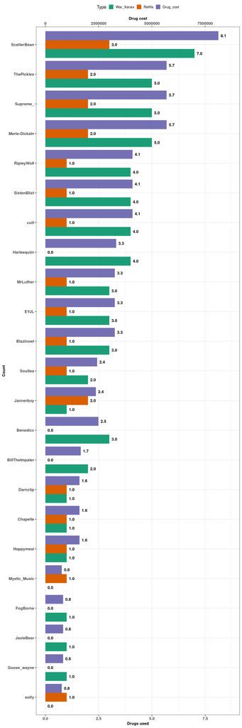

### Booster and can usage

Energy can and Booster usage during the war.

Total Boosters used: **3**  
Booster costs: **39.1 M**  
Total Cans used: **12**  
Can costs: **23.72 M**

All Boosters are assumed to be FHCs and Can price is set to average market value for ALL cans.

Booster cost in plot is in 10s of millions.

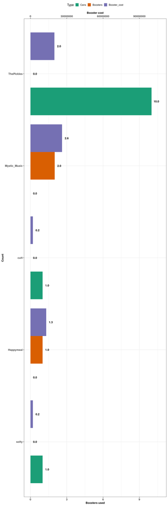

### Armory usage (BETA)

This is a summary of Armory usage during the preparation and war period.  
It can be useful for getting a good idea of how much consumables were used during the war in total.

<sup>1</sup> This section will be empty if you are using an API key WITHOUT faction access.

#### During preparation

```
## [1] "Preparation Armory usage:"
```

|  | Name | ID | action | amount | item | Hours_to_war |
| --- | --- | --- | --- | --- | --- | --- |
| 1 | Chapelle | 2852232 | used | 1 | Xanax | 119.44 |
| 2 | Benedicc | 2729522 | used | 1 | Bottle of Beer | 118.67 |
| 3 | RipleyWolf | 3719564 | used | 1 | Xanax | 117.27 |
| 4 | ScatterBean | 3383329 | used | 1 | Bottle of Beer | 116.78 |
| 5 | Supreme_ | 3153441 | used | 1 | Xanax | 116.48 |
| 6 | ThePickles | 3159219 | used | 1 | Xanax | 116.45 |
| 7 | cutt | 2944902 | used | 1 | Xanax | 116.03 |
| 8 | Supreme_ | 3153441 | used | 1 | Blood Bag : O- | 112.01 |
| 9 | Supreme_ | 3153441 | used | 1 | Blood Bag : O- | 112 |
| 10 | Supreme_ | 3153441 | used | 1 | Blood Bag : O- | 111.98 |

[output cut: 656 more lines]

```
## [1] "Preparation usage totals:"
```

|  | Action | Item | Count |
| --- | --- | --- | --- |
| 1 | used | Bottle of Beer | 321 |
| 2 | used | Box of Sweet Hearts | 151 |
| 3 | used | Xanax | 116 |
| 4 | used | Blood Bag : O- | 20 |
| 5 | used | Blood Bag : O+ | 19 |
| 6 | used | Cannabis | 12 |
| 7 | loaned | Pepper Spray | 11 |
| 8 | used | Blood Bag : A+ | 6 |
| 9 | used | LSD | 4 |
| 10 | used | Ecstasy | 2 |

[output cut: 11 more lines]

```
## [1] "Only showing consumables"
```

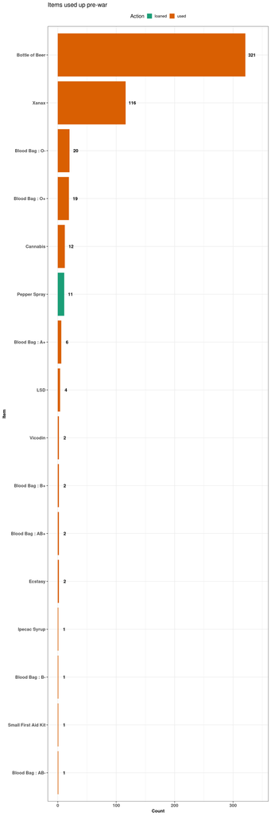

#### During war

```
## [1] "War Armory usage:"
```

|  | Name | ID | action | amount | item | Hours_to_end |
| --- | --- | --- | --- | --- | --- | --- |
| 1 | Goose_wayne | 2434584 | used | 1 | Blood Bag : A+ | 73.93 |
| 2 | Goose_wayne | 2434584 | used | 1 | Blood Bag : A+ | 73.92 |
| 3 | Goose_wayne | 2434584 | used | 1 | Blood Bag : A+ | 73.92 |
| 4 | Goose_wayne | 2434584 | used | 1 | Ipecac Syrup | 73.91 |
| 5 | MirandaWarning | 3676666 | used | 1 | First Aid Kit | 73.65 |
| 6 | MirandaWarning | 3676666 | used | 1 | First Aid Kit | 73.65 |
| 7 | MirandaWarning | 3676666 | used | 1 | First Aid Kit | 73.65 |
| 8 | MirandaWarning | 3676666 | used | 1 | First Aid Kit | 73.65 |
| 9 | MirandaWarning | 3676666 | used | 1 | First Aid Kit | 73.65 |
| 10 | MirandaWarning | 3676666 | used | 1 | First Aid Kit | 73.65 |

[output cut: 920 more lines]

```
## [1] "War usage totals:"
```

|  | Action | Item | Count |
| --- | --- | --- | --- |
| 1 | used | Box of Sweet Hearts | 213 |
| 2 | used | Blood Bag : O+ | 172 |
| 3 | used | Bottle of Beer | 159 |
| 4 | used | Blood Bag : A+ | 92 |
| 5 | used | Xanax | 61 |
| 6 | loaned | Pepper Spray | 57 |
| 7 | used | Blood Bag : A- | 48 |
| 8 | used | Blood Bag : O- | 41 |
| 9 | used | Blood Bag : AB+ | 31 |
| 10 | used | Blood Bag : B- | 24 |

[output cut: 14 more lines]

```
## [1] "Only showing consumables"
```

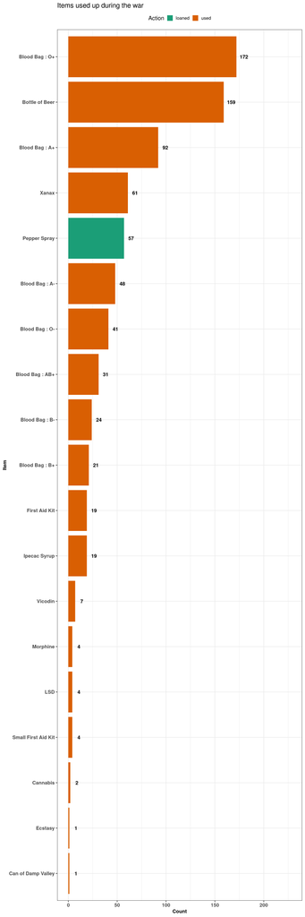

### Activity

Member activity during the war in hours.

```
## [1] "Correlation between activity and contribution:"
```

```
## [1] 0.6
```

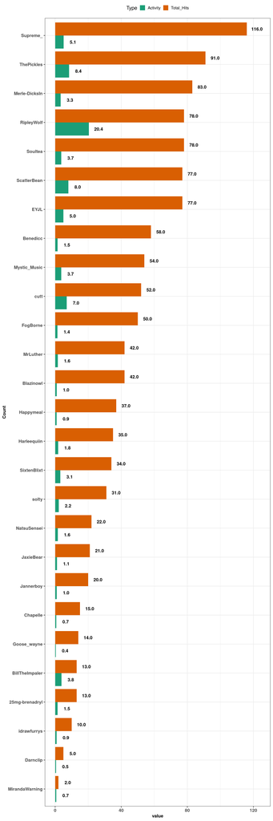

### Hospital

Summary of times hospitalized during the war

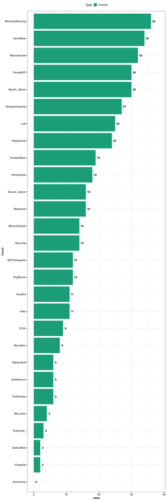

### Full table

|  | Name | War_Xanax | Refills | Boosters | Cans | Drug_cost | Booster_cost | Activity | Hospital |
| --- | --- | --- | --- | --- | --- | --- | --- | --- | --- |
| 1 | solty | 0 | 1 | 0 | 1 | 772200 | 1976892.44 | 2.17 | 11 |
| 2 | Blazinowl | 3 | 1 | 0 | 0 | 3259935 | 0 | 1.01 | 16 |
| 3 | Happymeal | 1 | 1 | 1 | 0 | 1601445 | 13033070 | 0.87 | 24 |
| 4 | Goose_wayne | 1 | 0 | 0 | 0 | 829245 | 0 | 0.37 | 16 |
| 5 | JaxieBear | 1 | 0 | 0 | 0 | 829245 | 0 | 1.08 | 34 |
| 6 | Benedicc | 3 | 0 | 0 | 0 | 2487735 | 0 | 1.51 | 8 |
| 7 | Jannerboy | 1 | 2 | 0 | 0 | 2373645 | 0 | 0.98 | 0 |
| 8 | FogBorne | 1 | 0 | 0 | 0 | 829245 | 0 | 1.43 | 12 |
| 9 | Chapelle | 1 | 1 | 0 | 0 | 1601445 | 0 | 0.7 | 2 |
| 10 | Darnclip | 1 | 1 | 0 | 0 | 1601445 | 0 | 0.49 | 14 |

[output cut: 18 more lines]

## AI summary (BETA)

This is an experimental portion of the report - an overview of the war generated by AI.  
When looking at this section, keep that in mind and take the results with a grain of salt.  
Before taking any actions that might impact faction members mentioned in this summary, double-check that there are no mistakes or missed key details.

Here is a summary of the provided combat data:

### Overall Faction Performance

The faction shows a mixed performance overall. A good proportion of members participated in the war, indicated by a number of non-zero war hits. There are also a number of members with positive Net_Scores.

### Areas for Improvement

- **E_Wasted Reduction:** A significant opportunity for improvement lies in reducing wasted energy (E_Wasted).
- **Hospital Visits:** While not of major concern, the total number of hospital visits could be lower, especially if it correlates with negative Net_Scores.

### Individual Highlights: Positive

- **EYJL:** High War_Hits (76), decent Assists (2), and a very high Net_Score (318.13) indicate strong offensive capabilities and contribution to the war effort.
- **Merle-DicksIn:** High War_Hits (82) with a high Net_Score (326.07), is a significant contributor.
- **ThePickles:** Significant Activity (8.422 hours), a high number of Total_Hits (91), and a very high Net_Score (471.72). This member demonstrated high engagement and effectiveness.
- **RipleyWolf:** Exceptionally high Activity (20.399 hours) and a very high Net_Score (430.07), suggesting a very active and impactful participation.

### Individual Highlights: Negative

- **SomeBOT:** Zero War_Hits and a negative Net_Score (-135.29) indicates a lack of participation and a negative impact during the war.
- **MirandaWarning:** Zero War_Hits and a negative Net_Score (-90.25) suggests a lack of engagement.
- **NatsuSensei:** High Hospital visits (32) and a negative Net_Score (-98.35), is not an effective participant.
- **Goose_wayne:** Net_Score of -121.64.
- **JaxieBear:** Net_Score of -144.84.